# Binomial Distribution Response to Urban Heat - Portland

2025-10-06

```r
library(tidyverse)
library(corrplot)
library(knitr)
library(kableExtra)
#library(gghalves)
library(patchwork)
library(scales)
library(glmmTMB)
library(bbmle)
library(DHARMa)
```

# Purpose

The purpose of this page is to summarize an investigation of **tree health categories** as a *categorical* response to urban heat (temperatures) for observations from Portland, Oregon.

Response variable: category: *healthy, unhealthy*

*Response variables* Binary health: healthy, unhealthy Binary dead top: no top dieback, top dieback Binary thinning: no thinning, thinning

# Data Wrangling

```r
data <- read.csv('https://raw.githubusercontent.com/jmhulbert/redhot2/refs/heads/main/data/urban-data-modified.csv')
```

## Remove dead trees

```r
# Remove Dead Trees
data.w.dead <- data
data <- data %>% filter(field.tree.canopy.symptoms!="Tree is dead") %>% filter(field.dieback.percent<100) %>% droplevels()
```

113 trees were dead

```r
data$binary.tree.canopy.symptoms <- as.factor(data$binary.tree.canopy.symptoms)
levels(data$binary.tree.canopy.symptoms)
```

```
## [1] "Healthy"   "Unhealthy"
```

## Filter to Portland Data

```r
data <- data %>% filter(Area=="Portland") %>% droplevels()
```

451 trees were included in portland

## Subset data from parks

```r
parks <- data %>% filter(str_detect(place_guess, "Park") | str_detect(place_guess, "park") | str_detect(place_guess, "Hoyt") |str_detect(place_guess, "hoyt")) %>% mutate(park = str_remove(place_guess, ",.*"))
levels(as.factor(parks$park))
```

```
##  [1] "Cathedral City Park"                "Columbia Park and Annex"
##  [3] "Creston Park"                       "Duniway Park"
##  [5] "Ed Benedict Park"                   "Elizabeth Caruthers Park"
##  [7] "Explore Washington Park"            "Forest Park Conservancy"
##  [9] "Gabriel Park"                       "George Himes Park"
## [11] "Hoyt Arboretum"                     "Lair Hill Park"
## [13] "Lents Park"                         "Montavilla City Park"
## [15] "Mt. Tabor Park"                     "NE Hoyt St"
## [17] "Overlook Park"                      "Powell Butte Nature Park"
## [19] "Rose City Park"                     "SW Sam Jackson Park Rd"
## [21] "Trenton Park"                       "TriMet Washington Park MAX Station"
## [23] "Washington park"                    "Washington Park"
## [25] "Willamette Park"                    "Woodstock City Park"
```

## Observations from Hoyt

```r
hoyt.data <- data %>% filter(str_detect(place_guess, "Hoyt") |str_detect(place_guess, "hoyt"))
```

109 trees were from hoyt

## Remove observations from Hoyt

```r
data.w.hoyt <- data
data <- data %>% filter(!str_detect(place_guess, "Hoyt") & !str_detect(place_guess, "hoyt"))
```

# Visualize Portland Data

## All Portland

```r
#ggplot(data,aes(binary.tree.canopy.symptoms,pl.af.f,fill=binary.tree.canopy.symptoms))+geom_violin()+coord_flip()+theme_bw()+ scale_fill_manual(name="Tree Condition",values=c("#7fcdbb","#fe9929"))+guides(fill=FALSE)
```

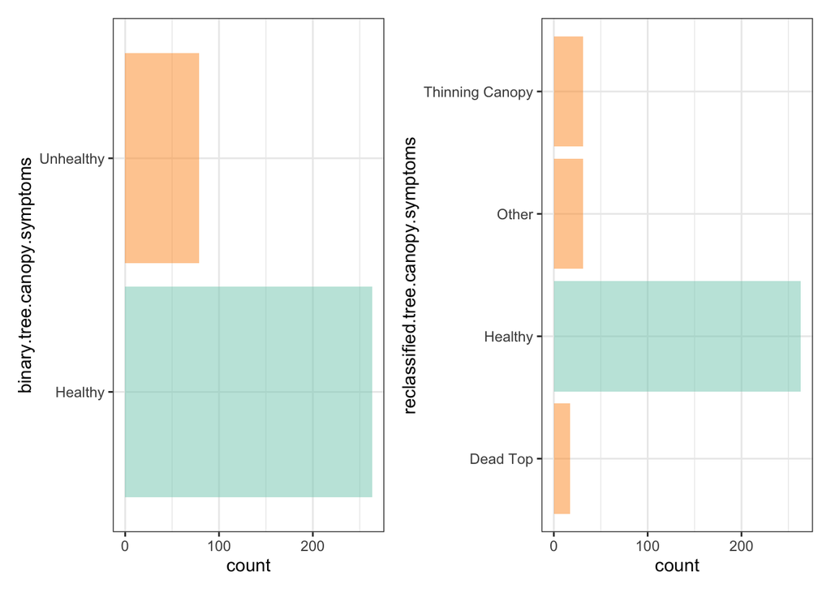

```r
p1 <- ggplot(data,aes(binary.tree.canopy.symptoms,fill=binary.tree.canopy.symptoms))+geom_histogram(stat="count",alpha=0.5)+theme_bw()+coord_flip()+ scale_fill_manual(name="Tree Condition",values=c("#7fcdbb","#fe9929"))+guides(fill=FALSE)
p2 <- ggplot(data,aes(reclassified.tree.canopy.symptoms,fill=reclassified.tree.canopy.symptoms))+geom_histogram(stat="count",alpha=0.5)+theme_bw()+coord_flip()+ scale_fill_manual(values=c("#fe9929","#7fcdbb","#fe9929","#fe9929"))+guides(fill=FALSE)
p1 + p2
```

```r
#p3 <- ggplot(data,aes(binary.tree.canopy.symptoms)) +facet_wrap(~field.optional...tree.size) +geom_histogram(stat="count")+theme_bw()+coord_flip()
#p3
```

```r
#p4 <- ggplot(data,aes(binary.tree.canopy.symptoms)) +facet_wrap(~field.optional...site.location.description) +geom_histogram(stat="count")+theme_bw()+coord_flip()
#p4
```

```r
p5 <-ggplot(data,aes(binary.tree.canopy.symptoms,pl.af.f, fill=binary.tree.canopy.symptoms ))+geom_boxplot(alpha=0.5)+theme_bw()+coord_flip() + scale_fill_manual(name="Tree Condition",values=c("#7fcdbb","#fe9929"))+guides(fill=FALSE) +labs(x="Tree Condition",y=NULL)
```

```r
p6 <-ggplot(data,aes(pl.af.f,fill=binary.tree.canopy.symptoms))+geom_density(alpha=0.5) + scale_fill_manual(name="Tree Condition",values=c("#7fcdbb","#fe9929")) +theme_bw() +labs(x="Afternoon Temperature") +guides(fill=FALSE)
```

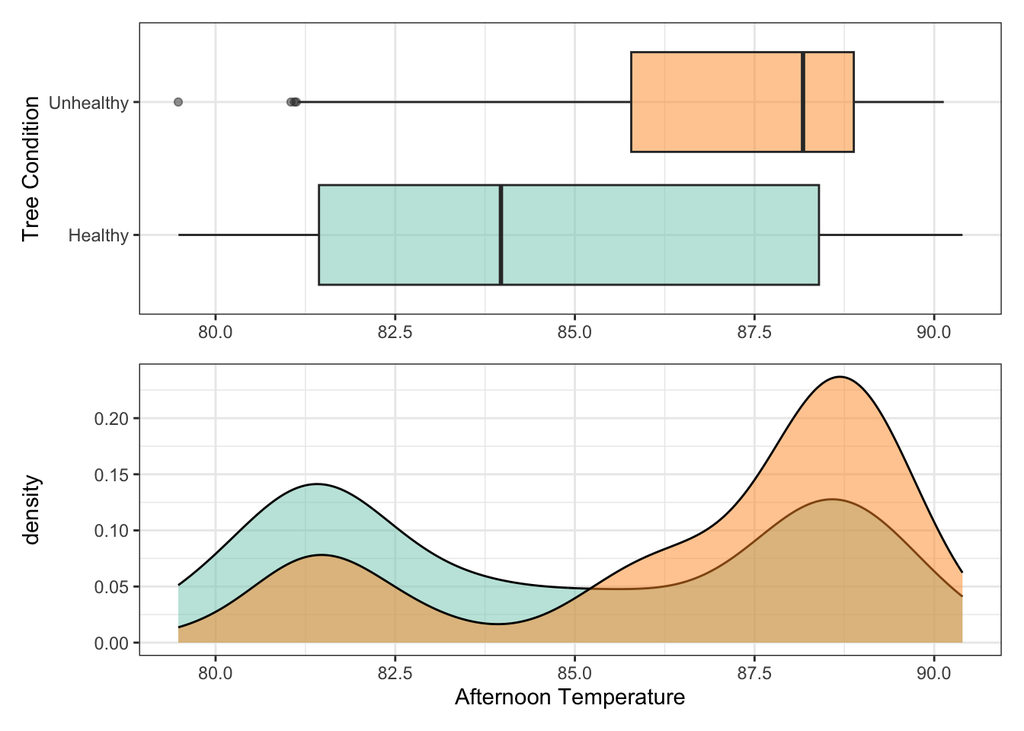

```r
p5 / p6
```

## Parks Observations

```r
places.summary <- data.w.hoyt %>% group_by(place_guess) %>%summarize(n=n(),n.healthy=sum(binary.tree.canopy.symptoms == "Healthy", na.rm = TRUE),n.unhealthy=sum(binary.tree.canopy.symptoms == "Unhealthy", na.rm = TRUE)) %>% mutate(prop.unhealthy =n.unhealthy/n.healthy) %>% mutate(prop.group = factor(if_else(prop.unhealthy > 0.2, "high", "low"),levels = c("low", "high")))
places.summary <- places.summary %>% filter(n>=5) %>% droplevels()
parks$park[parks$park=="Washington park"] <-"Washington Park"

parks <- parks %>% filter(park!="NE Hoyt St") %>% filter(park!="TriMet Washington Park MAX Station")
```

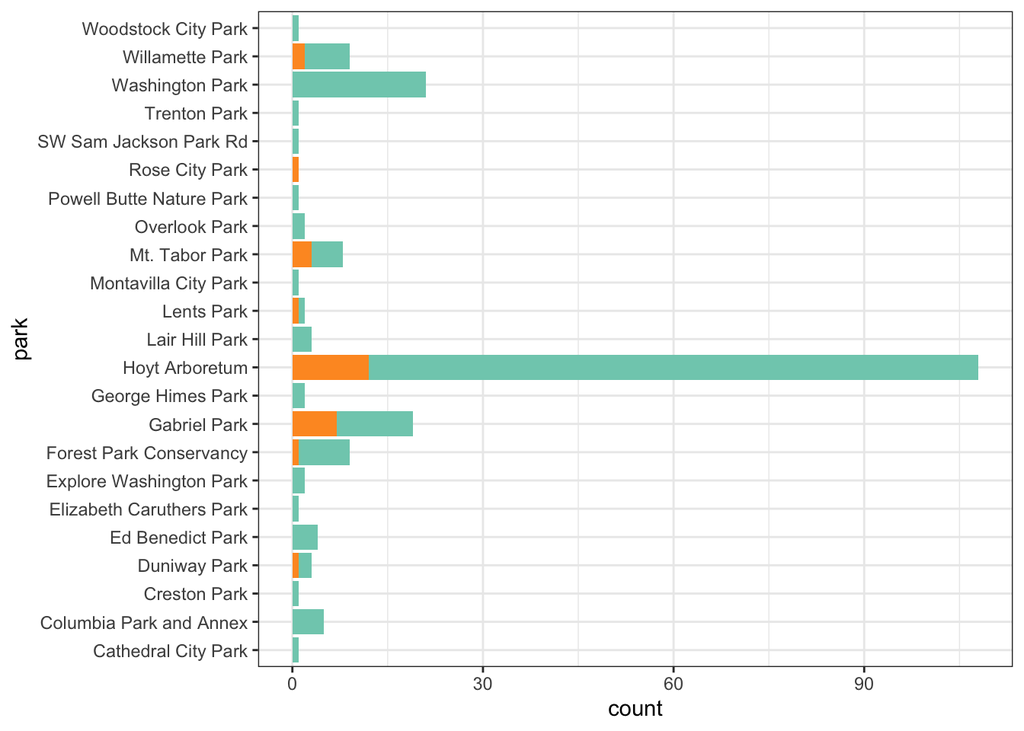

```r
ggplot(parks,aes(park,fill=binary.tree.canopy.symptoms))+geom_histogram(stat="count") +coord_flip() + guides(fill="none") + theme_bw() +scale_fill_manual(name="Tree Condition",values=c("#7fcdbb","#fe9929"))
```

```r
parks <- parks %>% filter(park =="Gabriel Park" | park== "Hoyt Arboretum"| park== "Mt. Tabor Park"| park== "Washington Park" | park=="Willamette Park" | park=="Forest Park Conservancy" | park=="Columbia Park and Annex")

parks.summary <- parks %>% group_by(park) %>% summarize(n=n(),n.healthy=sum(binary.tree.canopy.symptoms == "Healthy", na.rm = TRUE),n.unhealthy=sum(binary.tree.canopy.symptoms == "Unhealthy", na.rm = TRUE)) %>% mutate(prop.unhealthy =n.unhealthy/n.healthy) %>% mutate(prop.group = factor(if_else(prop.unhealthy > 0.2, "high", "low"),levels = c("low", "high"))) %>% mutate(park = factor(park, levels = c("Willamette Park","Washington Park","Mt. Tabor Park","Hoyt Arboretum","Gabriel Park","Forest Park Conservancy","Columbia Park and Annex")))
```

```r
p7 <- ggplot(parks,aes(binary.tree.canopy.symptoms,pl.af.f, fill=binary.tree.canopy.symptoms ))+geom_boxplot(alpha=0.5) +facet_wrap(~park,ncol=1) +theme_bw()+coord_flip() + scale_fill_manual(name="Tree Condition",values=c("#7fcdbb","#fe9929"))+guides(fill=FALSE) +labs(x="Tree Condition",y="Temperature (F)")

p8 <- ggplot(parks.summary,aes(park,prop.unhealthy,fill=prop.group))+geom_col()+coord_flip()+theme_bw()+geom_text(aes(label=n),hjust = -0.2) + scale_fill_manual(name="Proportion",values=c("#7fcdbb","#fe9929"))+guides(fill=FALSE) + labs(y="Proportion of Trees Categorized as Unhealthy (n=total)",x="Portland Park")
```

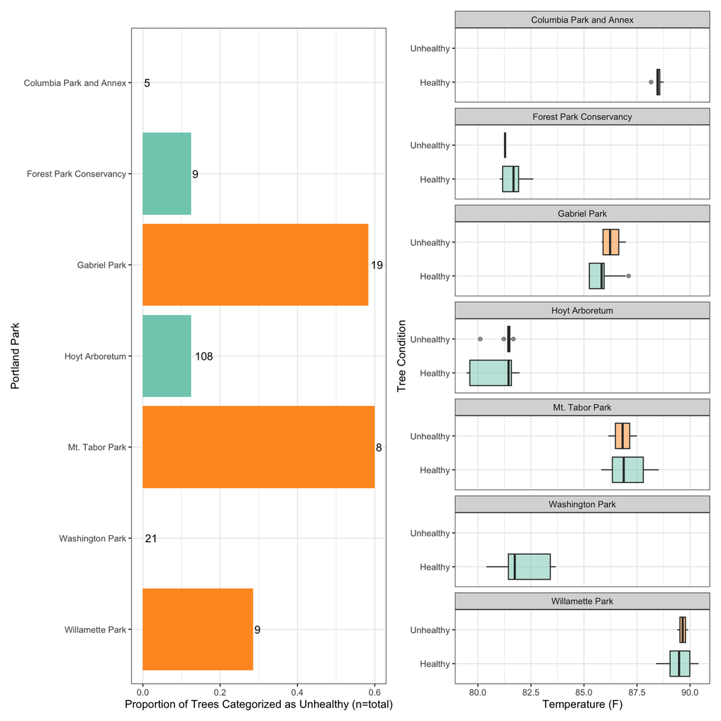

```r
p8 + p7
```

# Analyses

```r
data$top.dieback <- as.factor(data$top.dieback)
data$thinning <- as.factor(data$thinning)
```

Models were created with data after removing hoyt

## Temperature Time Periods

```r
binomial.daily <- glmmTMB(binary.tree.canopy.symptoms ~ mean.temp.daily.f ,family=binomial,data=data)
binomial.am <- glmmTMB(binary.tree.canopy.symptoms ~ pl.am.f ,data=data,family=binomial)
binomial.af <- glmmTMB(binary.tree.canopy.symptoms ~ pl.af.f ,data=data,family=binomial)
binomial.pm <- glmmTMB(binary.tree.canopy.symptoms ~ pl.pm.f,data=data,family=binomial)
```

### Best Fit Comparison

```r
AICtab(binomial.daily,binomial.am,binomial.af,binomial.pm)
```

```
##                dAIC df
## binomial.af     0.0 2
## binomial.daily 10.0 2
## binomial.pm    21.2 2
## binomial.am    22.5 2
```

Afternoon heat was the best fit

## Response 1.0: healthy / unhealthy

```r
binomial.af <- glmmTMB(binary.tree.canopy.symptoms ~ pl.af.f ,data=data,family=binomial)
```

### Summary

```r
summary(binomial.af)
```

```
##  Family: binomial  ( logit )
## Formula:          binary.tree.canopy.symptoms ~ pl.af.f
## Data: data
##
##       AIC       BIC    logLik -2*log(L)  df.resid
##     351.1     358.8    -173.6     347.1       340
##
##
## Conditional model:
##              Estimate Std. Error z value Pr(>|z|)
## (Intercept) -17.44991    3.66917  -4.756 1.98e-06 ***
## pl.af.f       0.18952    0.04249   4.461 8.18e-06 ***
## ---
## Signif. codes:  0 '***' 0.001 '**' 0.01 '*' 0.05 '.' 0.1 ' ' 1
```

Tree health is associated with urban heat. The probability of success (tree categorized as unhealthy) increases with urban heat

Unhealthy trees are considered success (1) because it is the second level. The probability of failure (0) is the first level (Healthy).

```r
levels(data$binary.tree.canopy.symptoms)
```

```
## [1] "Healthy"   "Unhealthy"
```

The probability of a tree being classified as unhealthy increases with urban temperature.

### Visualize effects of predictors

First, generate predictions from model

```r
# Create a data frame for predictions
new.data <- expand.grid(
  pl.af.f = seq(min(data$pl.af.f), max(data$pl.af.f), length.out = 100)  # keeping predictor2 constant at its mean
)
```

```r
head(new.data)
```

```
##    pl.af.f
## 1 79.48087
## 2 79.59110
## 3 79.70133
## 4 79.81157
## 5 79.92180
## 6 80.03203
```

```r
new.data$predicted_response <- predict(binomial.af, newdata = new.data, type = "response")
```

```r
head(new.data)
```

```
##    pl.af.f predicted_response
## 1 79.48087         0.08418609
## 2 79.59110         0.08581081
## 3 79.70133         0.08746390
## 4 79.81157         0.08914572
## 5 79.92180         0.09085666
## 6 80.03203         0.09259711
```

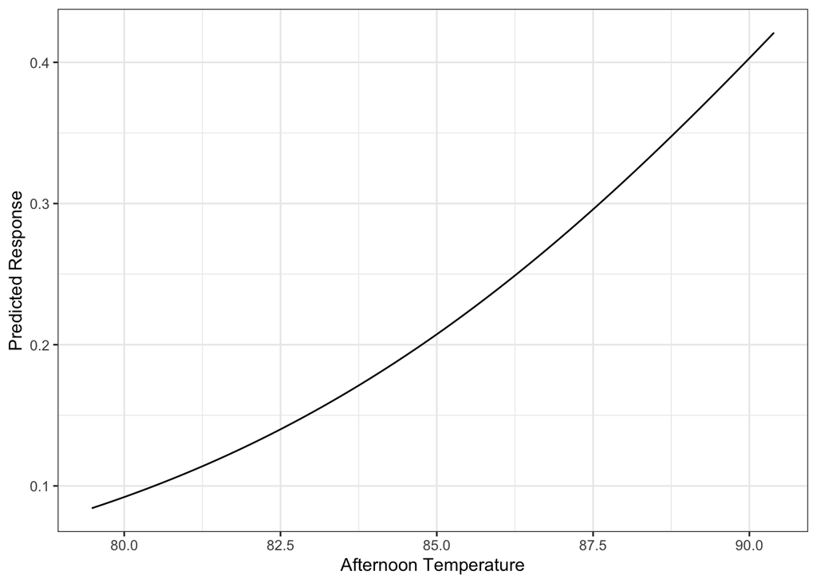

```r
ggplot(new.data, aes(x = pl.af.f, y = predicted_response)) +
  geom_line() +
  labs(x = "Afternoon Temperature", y = "Predicted Response") +
  theme_bw()
```

The probability of tree being classified as unhealthy increases with afternoon temperature

## Response 2.0: healthy / top-dieback

```r
data.top <- data %>% filter(reclassified.tree.canopy.symptoms=="Healthy"|reclassified.tree.canopy.symptoms=="Dead Top") %>% droplevels()
```

```r
top.dieback.binomial.af <- glmmTMB(top.dieback ~ pl.af.f,data=data.top,family=binomial)
```

### Summary

```r
summary(top.dieback.binomial.af)
```

```
##  Family: binomial  ( logit )
## Formula:          top.dieback ~ pl.af.f
## Data: data.top
##
##       AIC       BIC    logLik -2*log(L)  df.resid
##     115.3     122.5     -55.6     111.3       278
##
##
## Conditional model:
##             Estimate Std. Error z value Pr(>|z|)
## (Intercept) -35.7622    10.5366  -3.394 0.000689 ***
## pl.af.f       0.3814     0.1198   3.182 0.001460 **
## ---
## Signif. codes:  0 '***' 0.001 '**' 0.01 '*' 0.05 '.' 0.1 ' ' 1
```

```r
levels(data$top.dieback)
```

```
## [1] "No"  "Yes"
```

The probability of a tree having top dieback increases with urban temperature.

### Visualize effects of predictors

First, generate predictions from model

```r
# Create a data frame for predictions
new.data.2 <- expand.grid(
  pl.af.f = seq(min(80), max(150), length.out = 1000)  # keeping predictor2 constant at its mean
)
```

```r
head(new.data.2)
```

```
##    pl.af.f
## 1 80.00000
## 2 80.07007
## 3 80.14014
## 4 80.21021
## 5 80.28028
## 6 80.35035
```

```r
new.data.2$predicted_response <- predict(top.dieback.binomial.af, newdata = new.data.2, type = "response")
```

```r
# Create a data frame for predictions
new.data.2.inf <- expand.grid(
  pl.af.f = seq(min(data.top$pl.af.f), max(150), length.out = 1000)  # keeping predictor2 constant at its mean
)
```

```r
new.data.2.inf$predicted_response <- predict(top.dieback.binomial.af, newdata = new.data.2.inf, type = "response")
```

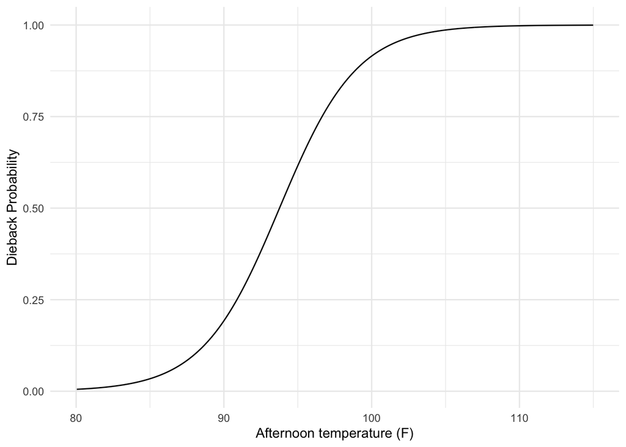

```r
p <- ggplot(new.data.2.inf, aes(x = pl.af.f, y = predicted_response)) + geom_line() + labs(x = "Afternoon temperature (F)", y = "Dieback Probability") + scale_x_continuous(limits = c(80, 115)) +theme_minimal()

p
```

### Calculate Dieback Probability Categories

```r
head(new.data.2[new.data.2$pl.af.f<85.5 & new.data.2$pl.af.f>84.75,])
```

```
##     pl.af.f predicted_response
## 69 84.76476         0.03132134
## 70 84.83483         0.03214244
## 71 84.90490         0.03298434
## 72 84.97497         0.03384752
## 73 85.04505         0.03473248
## 74 85.11512         0.03563972
```

Portland redcedar at 85 degrees had a 0.03 probability

```r
head(new.data.2[new.data.2$predicted_response>0.023 & new.data.2$predicted_response<0.027,])
```

```
##     pl.af.f predicted_response
## 58 83.99399         0.02353116
## 59 84.06406         0.02415313
## 60 84.13413         0.02479113
## 61 84.20420         0.02544554
## 62 84.27427         0.02611676
## 63 84.34434         0.02680520
```

Portland redcedar at 84.32 degrees had a 0.025 probability

```r
head(new.data.2[new.data.2$predicted_response>0.048 & new.data.2$predicted_response<0.052,])
```

```
##     pl.af.f predicted_response
## 86 85.95596         0.04846224
## 87 86.02603         0.04970965
## 88 86.09610         0.05098744
```

```r
head(new.data.2[new.data.2$predicted_response>0.09,])
```

```
##      pl.af.f predicted_response
## 111 87.70771         0.09036809
## 112 87.77778         0.09258918
## 113 87.84785         0.09485917
## 114 87.91792         0.09717885
## 115 87.98799         0.09954902
## 116 88.05806         0.10197047
```

```r
head(new.data.2[new.data.2$predicted_response>0.195 & new.data.2$predicted_response<0.205,])
```

```
##      pl.af.f predicted_response
## 145 90.09009          0.1977414
## 146 90.16016          0.2020155
```

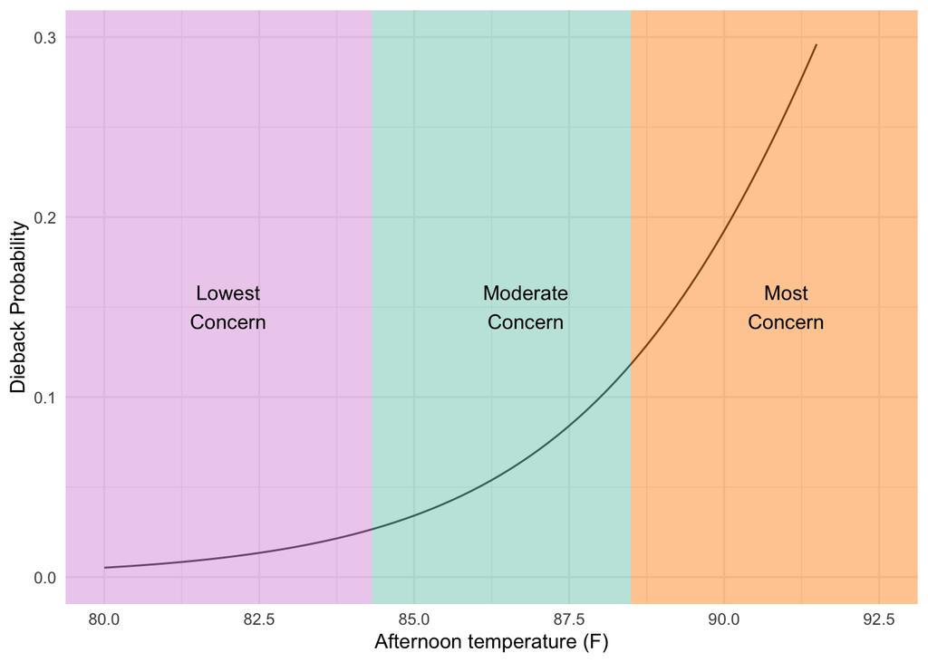

```r
p <- ggplot(new.data.2, aes(x = pl.af.f, y = predicted_response)) + geom_line() + labs(x = "Afternoon temperature (F)", y = "Dieback Probability") + scale_x_continuous(limits = c(80, 92.5),breaks=c(80,82.5,85,87.5,90,92.5)) + scale_y_continuous(limits = c(0, .3)) +theme_minimal()

p2 <- p + annotate(geom="rect",ymin = -Inf, ymax = Inf,
              xmin = -Inf, xmax = 84.32, fill = alpha('#DDA0DD',0.5)) +
    annotate(geom="rect",ymin = -Inf, ymax = Inf,
              xmin = 84.32, xmax = 88.5, fill = alpha('#7fcdbb',0.5)) +
    annotate(geom="rect",ymin = -Inf, ymax = Inf,
          xmin = 88.5, xmax = Inf, fill = alpha('#fe9929',0.5))
p3 <- p2 + annotate("text", x=82, y=.15, label= "Lowest\nConcern") + annotate("text", x=86.8, y=.15, label= "Moderate\nConcern") + annotate("text", x=91, y=.15, label= "Most\nConcern")
p3
```

The probability of a tree having top dieback increases with afternoon temperature

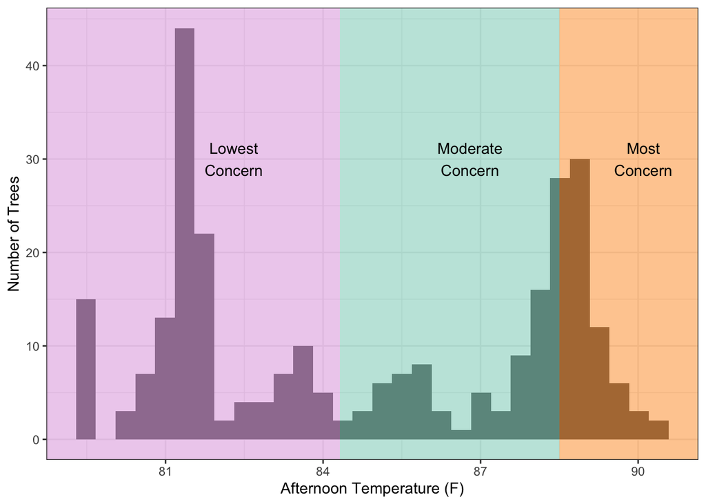

```r
p <- ggplot(data.top, aes(x=pl.af.f))+geom_histogram() +theme_bw() +labs(y="Number of Trees",x="Afternoon Temperature (F)")
p2 <- p + annotate(geom="rect",ymin = -Inf, ymax = Inf,
              xmin = -Inf, xmax = 84.32, fill = alpha('#DDA0DD',0.5)) +
    annotate(geom="rect",ymin = -Inf, ymax = Inf,
              xmin = 84.32, xmax = 88.5, fill = alpha('#7fcdbb',0.5)) +
    annotate(geom="rect",ymin = -Inf, ymax = Inf,
          xmin = 88.5, xmax = Inf, fill = alpha('#fe9929',0.5))
p3 <- p2 + annotate("text", x=82.3, y=30, label= "Lowest\nConcern") + annotate("text", x=86.8, y=30, label= "Moderate\nConcern") + annotate("text", x=90.1, y=30, label= "Most\nConcern")
p3
```

## Response 3.0: healthy / thinning

```r
data.thin <- data %>% filter(reclassified.tree.canopy.symptoms=="Healthy"|reclassified.tree.canopy.symptoms=="Thinning Canopy") %>% droplevels()
```

```r
thinning.binomial.af <- glmmTMB(thinning ~ pl.af.f,data=data.thin,family=binomial)
```

### Summary

```r
summary(thinning.binomial.af)
```

```
##  Family: binomial  ( logit )
## Formula:          thinning ~ pl.af.f
## Data: data.thin
##
##       AIC       BIC    logLik -2*log(L)  df.resid
##     199.2     206.6     -97.6     195.2       292
##
##
## Conditional model:
##              Estimate Std. Error z value Pr(>|z|)
## (Intercept) -10.28650    4.90027  -2.099   0.0358 *
## pl.af.f       0.09562    0.05715   1.673   0.0943 .
## ---
## Signif. codes:  0 '***' 0.001 '**' 0.01 '*' 0.05 '.' 0.1 ' ' 1
```

```r
levels(data.thin$thinning)
```

```
## [1] "No"  "Yes"
```

```r
str(data.thin$thinning)
```

```
##  Factor w/ 2 levels "No","Yes": 1 1 1 1 1 1 1 1 1 1 ...
```

There was no evidence the probability of a tree being classified as thinning is related to afternoon heat.

### Visualize effects of predictors

First, generate predictions from model

```r
# Create a data frame for predictions
new.data.3 <- expand.grid(
  pl.af.f = seq(min(data.thin$pl.af.f), max(data.thin$pl.af.f), length.out = 100),  # keeping predictor2 constant at its mean
  Area = 0  # assuming random effect is zero for prediction
)
```

```r
new.data.3$predicted_response <- predict(thinning.binomial.af, newdata = new.data.3, type = "response")
```

[figure not shown]

```r
ggplot(new.data.3, aes(x = pl.af.f, y = predicted_response)) +
  geom_line() +
  labs(x = "Distance from Mean Temperature", y = "Dieback Probability") +
  theme_minimal()
```